# Saezlab basic transcriptomic analysis template

Saezlab

19 January, 2022

# About

This is a boilerplate for general transcriptomic analyses using limma for differential expression and Saezlab tools for the advanced analyses. It contains the following analysis types:

- Bulk RNA-Seq data quality control and normalization
- Differential expression analysis (using limma)
- Functional analysis with MSigDB and decoupleR
- Footprint-based analysis with DoRothEA and PROGENy

The HTML document is knit using the `rmdformats` package to the working directory. Currently, there is no GitHub Actions workflow to automatically publish analysis HTML files, so distribution and publishing has to be performed manually.

# Setup

## Package installation

```r
# CRAN packages
cran_packages <- c("tidyverse", "msigdbr", "BiocManager")
for (i in cran_packages) {
  if (!i %in% rownames(installed.packages()))
    install.packages(i)
}

# BioC packages
bioc_packages <-
  c("decoupleR", "progeny", "dorothea", "limma", "edgeR", "decoupleR")
for (i in bioc_packages) {
  if (!i %in% rownames(installed.packages()))
    BiocManager::install(i, update = FALSE)
}
```

Analysing RNA-Seq data using `limma` and `edgeR`: [Law et al. 2016](https://f1000research.com/articles/5-1408/v3). Alternative using `DESeq2`: [tutorial](http://bioconductor.org/packages/devel/bioc/vignettes/DESeq2/inst/doc/DESeq2.html).

## Load packages and data

```r
success <- lapply(c(cran_packages, bioc_packages), require, character.only = TRUE)
if(!all(unlist(success))) print("There seems to be a problem loading one or more packages.")
```

Placeholder expression and meta data from [“Genomic Characterization of Cisplatin Response Uncovers Priming of Cisplatin-Induced Genes in a Resistant Cell Line”](https://www.mdpi.com/1422-0067/22/11/5814).

```r
counts <-
  read.table(
    "data/counts.tsv",
    header = TRUE,
    sep = "\t",
    row.names = 1
  )
metadata <- readr::read_tsv("data/metadata.tsv")
```

## Glimpse at expression

```r
head(counts)
```

```
##          A2780_rep1 A2780_rep2 A2780_rep3 Acis_rep1 Acis_rep2 Acis_rep3
## TSPAN6          471        477        426       104       112        84
## TNMD             15         15          7         0         0         0
## DPM1            322        299        279       232       242       224
## SCYL3           189        213        162        97       126       115
## C1orf112        388        389        365       325       318       259
## CFH            1860       1822       1710      1983      2066      1945
```

## Glimpse at metadata

```r
metadata %>% glimpse()
```

```
## Rows: 6
## Columns: 2
## $ id    <chr> "A2780_rep1", "A2780_rep2", "A2780_rep3", "Acis_rep1", "Acis_rep…
## $ group <chr> "sensitive", "sensitive", "sensitive", "resistant", "resistant",…
```

# Quality control and pre-processing

## Check library size

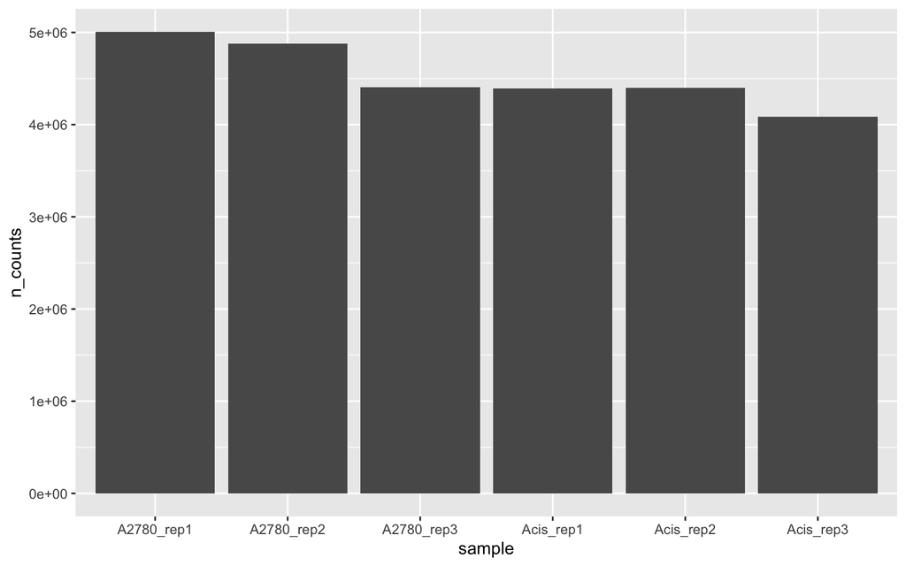

```r
data.frame(sample = colnames(counts), n_counts = colSums(counts)) %>%
  ggplot2::ggplot(aes(x = sample, y = n_counts)) +
  ggplot2::geom_col() +
  ggplot2::scale_y_continuous()
```

## Filter lowly expressed genes

```r
min_counts <- 10

# apply fitlerByExpr function to retrieve a boolean vector indicating which genes should be retained
design_matrix <- model.matrix( ~ 0 + group, data = metadata)
keep <- edgeR::filterByExpr(counts, design = design_matrix, min.count = min_counts)

# use the boolean vector to filter the count matrix
counts_filtered <- counts[keep,]

# print a message to show the number of genes that are retrieved after filtering
message(
  "From ",
  nrow(counts),
  " genes, removing ",
  sum(!keep),
  " using filterByExpr(). The resulting count matrix contains ",
  nrow(counts_filtered),
  " genes."
)
```

```
## From 18630 genes, removing 5240 using filterByExpr(). The resulting count matrix contains 13390 genes.
```

Per-sample count distributions

```r
plot_count_distribution <- function(c) {

  p <- c %>%
    tibble::rownames_to_column(var = "gene_symbol") %>%
    tidyr::pivot_longer(-gene_symbol, names_to = "sample", values_to = "n_counts") %>%
    ggplot2::ggplot(aes(x = log2(n_counts + 1), fill = sample)) +
    ggplot2::geom_histogram(binwidth = 0.1) +
    ggplot2::facet_grid(rows = vars(sample))

  return(p)

}
```

Unfiltered counts

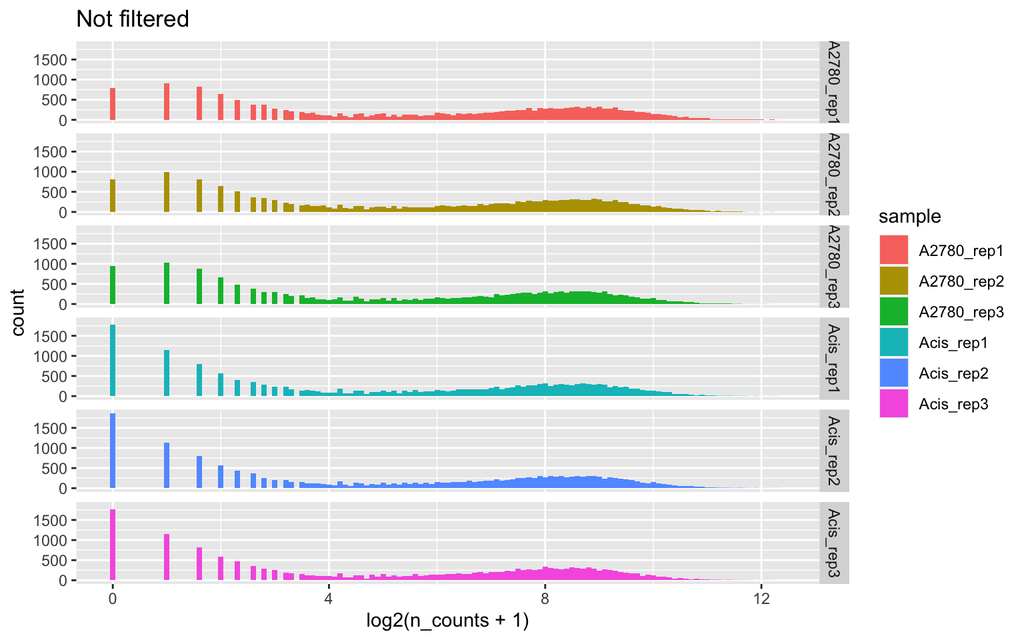

```r
plot_count_distribution(counts) +
  ggplot2::ggtitle("Not filtered")
```

Filtered counts

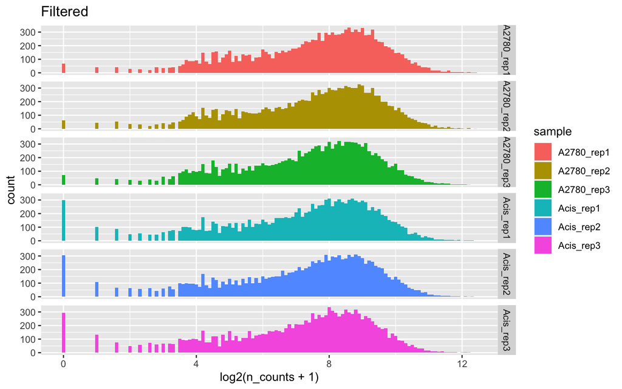

```r
plot_count_distribution(counts_filtered) +
  ggplot2::ggtitle("Filtered")
```

# Normalisation

We use the `calcNormFactors()` function from `edgeR` to calculate scaling factors for each sample. It uses the trimmed mean of M values (TMM), described in [Robinson et al. 2010](https://genomebiology.biomedcentral.com/articles/10.1186/gb-2010-11-3-r25).

```r
# create DGEList object
dge <-
  edgeR::DGEList(counts = counts_filtered, group = metadata$group)

# apply normalization function
dge_norm <- edgeR::calcNormFactors(dge, method = "TMM")
```

Generate a matrix of normalized gene expression values, using counts per million (CPM), and a $\log_2$ transformation.

```r
norm_expr <- edgeR::cpm(dge_norm, log = TRUE)
```

Glimpse at normalised expression

```r
head(norm_expr)
```

```
##          A2780_rep1 A2780_rep2 A2780_rep3 Acis_rep1 Acis_rep2 Acis_rep3
## TSPAN6     6.573658   6.634064   6.616629  4.593075  4.691209  4.384847
## DPM1       6.028097   5.964049   6.009471  5.735918  5.789353  5.780618
## SCYL3      5.266304   5.478889   5.232354  4.494460  4.858380  4.829742
## C1orf112   6.295424   6.341301   6.394761  6.218794  6.180606  5.988498
## CFH        8.550138   8.562763   8.616796  8.820767  8.872866  8.888483
## FUCA2      5.235803   5.338122   5.334274  4.760052  4.789093  4.673371
```

# Differential Expression Analysis

```r
# create the contrast matrix
contrasts <- c("groupresistant-groupsensitive")
contrast_matrix <-
  limma::makeContrasts(contrasts = contrasts,
                       levels = design_matrix)

# create linear model
fit <- limma::lmFit(norm_expr, design = design_matrix)

# fit contrasts
# "The coefficients, unscaled standard deviations and correlation matrix are re-calculated in terms of the contrasts."
fit_contrasts <-
  limma::contrasts.fit(fit, contrasts = contrast_matrix)

# compute moderated statistics using the global parameteres
ebayes_fit <- limma::eBayes(fit_contrasts)

# retrieve table of differentially expressed genes
de_table <- limma::topTable(ebayes_fit, number = Inf) %>%
  tibble::rownames_to_column(var = "gene")
```

## Glimpse at DE

```r
head(de_table)
```

```
##       gene     logFC  AveExpr         t      P.Value    adj.P.Val        B
## 1 DLX6-AS1 -9.973853 3.813716 -262.3526 2.673925e-13 2.700734e-09 18.82640
## 2    MEF2C -8.970600 3.312089 -231.6423 5.601056e-13 2.700734e-09 18.59825
## 3     PAX2 -9.018390 3.335984 -228.6486 6.050935e-13 2.700734e-09 18.57195
## 4     EYA4 -8.577307 3.115443 -214.1948 8.917741e-13 2.985214e-09 18.43243
## 5  NAALAD2 -8.222919 2.938249 -198.2238 1.412934e-12 3.342698e-09 18.25008
## 6   COL1A2 -8.581795 3.117687 -191.3908 1.740203e-12 3.342698e-09 18.16130
```

For more information about limma’s output, please see [here](https://support.bioconductor.org/p/6124/).

## DE summary

```r
summary(de_table)
```

```
##      gene               logFC               AveExpr              t
##  Length:13390       Min.   :-10.214733   Min.   : 0.2024   Min.   :-262.3526
##  Class :character   1st Qu.: -0.329065   1st Qu.: 3.6897   1st Qu.:  -4.0725
##  Mode  :character   Median : -0.007562   Median : 5.5092   Median :  -0.1098
##                     Mean   : -0.157601   Mean   : 5.1253   Mean   :  -1.4930
##                     3rd Qu.:  0.241790   3rd Qu.: 6.6562   3rd Qu.:   3.4227
##                     Max.   :  8.552186   Max.   :10.1200   Max.   : 142.4021
##     P.Value            adj.P.Val              B
##  Min.   :0.0000000   Min.   :0.000000   Min.   :-8.6989
##  1st Qu.:0.0002445   1st Qu.:0.000978   1st Qu.:-7.5038
##  Median :0.0104191   Median :0.020837   Median :-4.5690
##  Mean   :0.1456324   Mean   :0.167759   Mean   :-3.1538
##  3rd Qu.:0.1695559   3rd Qu.:0.226069   3rd Qu.:-0.3057
##  Max.   :0.9997481   Max.   :0.999748   Max.   :18.8264
```

## Distribution of the adjusted P values

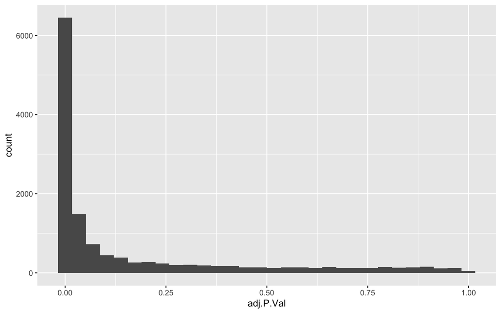

```r
ggplot2::ggplot(de_table, aes(x = adj.P.Val)) +
  ggplot2::geom_histogram()
```

## Volcano plot

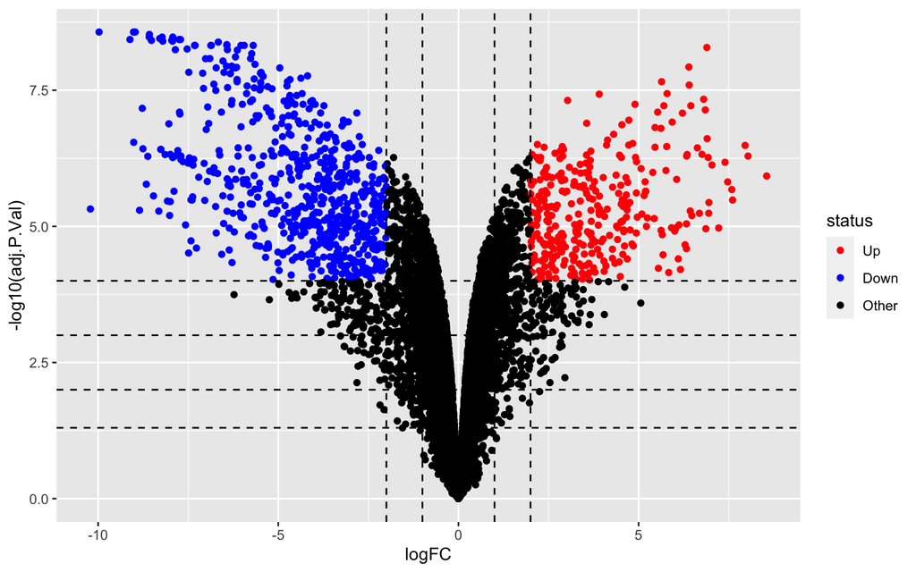

```r
# set cutoffsa
p_cutoff <- 0.0001
fc_cutoff <- 2

# annotate de_table with status according to cutoffs
de_table <- de_table %>%
  dplyr::mutate(
    status = dplyr::case_when(
      logFC >= fc_cutoff & adj.P.Val <= p_cutoff ~ "Up",
      logFC <= -fc_cutoff & adj.P.Val <= p_cutoff ~ "Down",
      TRUE ~ "Other"
    )
  )

#  volcano plots
ggplot2::ggplot(de_table, aes(x = logFC,-log10(adj.P.Val), color = status)) +
  ggplot2::geom_point() +
  ggplot2::geom_vline(xintercept = log2(c(0.25, 0.5, 2, 4)), lty = 2) +
  ggplot2::geom_hline(yintercept = -log10(c(0.05, 0.01, 0.001, 0.0001)), lty = 2) +
  ggplot2::scale_color_manual(values = c(
    "Up" = "red",
    "Down" = "blue",
    "Other" = "black"
  ))
```

# Functional analyses

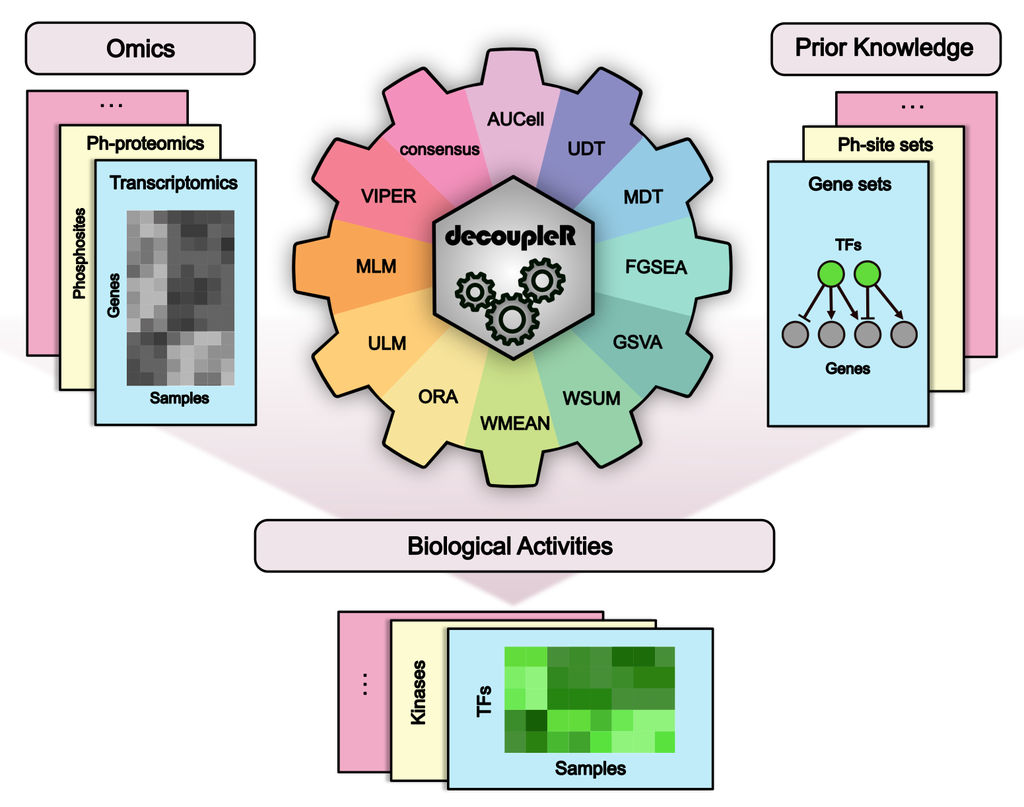

We perform the functional analysis using decoupleR. As `decoupleR` functions expect a matrix as input, we are going to create a one-column matrix from the `de_table` object. This one column matrix contains the vector of T values obtained from limma. We choose the T values over other metrics because it combines the confidence and magnitude values of differential expression.

```r
# create matrix
decoupler_input <- tibble::column_to_rownames(de_table, "gene") %>%
  dplyr::select(t) %>%
  dplyr::arrange(desc(t)) %>%
  as.matrix()
```

## T value distribution

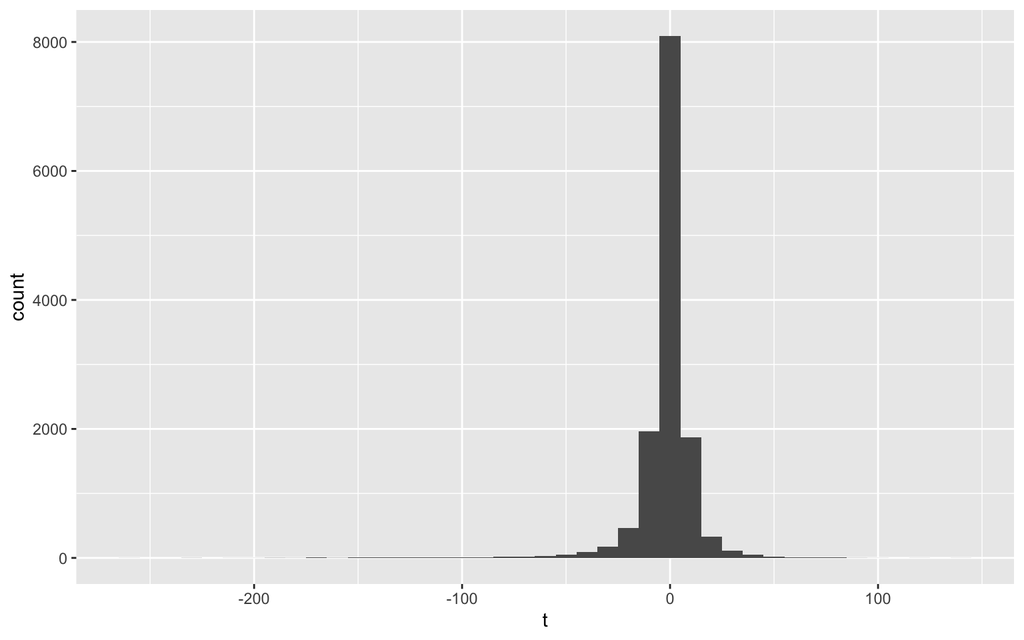

```r
de_table %>%
  dplyr::arrange(desc(t)) %>%
  dplyr::mutate(gene = forcats::fct_inorder(gene)) %>%
  ggplot2::ggplot(aes(x = t)) +
  ggplot2::geom_histogram(binwidth = 10)
```

## Load MSigDB data

Data from the [Molecular Signatures Database (MSigDB) database](https://www.gsea-msigdb.org/gsea/msigdb/), dataset WikiPathways.

```r
# retrieve GO terms table
wikipathways <- msigdbr::msigdbr(species = "Homo sapiens",
                                 category = "C2",
                                 subcategory = "CP:WIKIPATHWAYS")
```

Glimpse at dataset

```r
head(wikipathways)
```

```
## # A tibble: 6 × 15
##   gs_cat gs_subcat gs_name gene_symbol entrez_gene ensembl_gene human_gene_symb…
##   <chr>  <chr>     <chr>   <chr>             <int> <chr>        <chr>
## 1 C2     CP:WIKIP… WP_15Q… AC091304.1       645202 ENSG0000023… AC091304.1
## 2 C2     CP:WIKIP… WP_15Q… AC091304.1       645202 ENSG0000027… AC091304.1
## 3 C2     CP:WIKIP… WP_15Q… AC091304.1       645202 ENSG0000028… AC091304.1
## 4 C2     CP:WIKIP… WP_15Q… AC100756.2    102723623 ENSG0000027… AC100756.2
## 5 C2     CP:WIKIP… WP_15Q… AC100756.2    102723623 ENSG0000028… AC100756.2
## 6 C2     CP:WIKIP… WP_15Q… CYFIP1            23191 ENSG0000027… CYFIP1
## # … with 8 more variables: human_entrez_gene <int>, human_ensembl_gene <chr>,
## #   gs_id <chr>, gs_pmid <chr>, gs_geoid <chr>, gs_exact_source <chr>,
## #   gs_url <chr>, gs_description <chr>
```

Transform into `decoupleR`-compatible format

```r
# helper function to transform msigdb data frames into decoupler compatible data frames
msigdb_to_decoupler <- function(df) {

  output <- df %>%
    dplyr::transmute(
      source = gs_name,
      target = gene_symbol,
      mor = 1,
      likelihood = 1
    ) %>%
    dplyr::distinct()
  return(output)

}

# apply to data frame
wiki_decoupler <- msigdb_to_decoupler(wikipathways)
```

## Over-representation Analysis (ORA)

We select the **top N** up and down regulated genes according to their T values and evaluate which functional categories are over-represented using the `run_ora()` function from `decoupleR`:

```r
# set the top N
n_top <- 50

# run for up-regulated genes using n_up
ora_up <- decoupleR::run_ora(
  mat = decoupler_input,
  network = wiki_decoupler,
  n_up = n_top,
  n_bottom = 0,
  .source = "source",
  .target = "target"
) %>%
  dplyr::mutate(adj_p = p.adjust(p_value, method = "BH"))

# run for down-regulated genes using n_bottom
ora_down <- decoupleR::run_ora(
  mat = decoupler_input,
  network = wiki_decoupler,
  n_up = 0,
  n_bottom = n_top,
  .source = "source",
  .target = "target"
) %>%
  dplyr::mutate(adj_p = p.adjust(p_value, method = "BH"))

# bind both data frames
ora_results <- list(Up = ora_up, Down = ora_down) %>%
  dplyr::bind_rows(.id = "status") %>%
  dplyr::arrange(p_value)
```

Plot the top 10 up- and down-regulated functional categories:

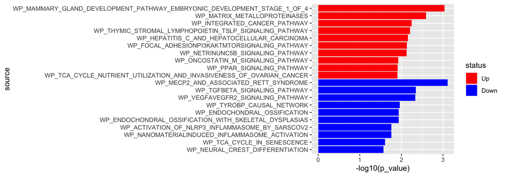

```r
# plot them
ora_results %>%
  dplyr::group_by(status) %>%
  dplyr::slice_head(n = 10) %>%
  dplyr::mutate(source = forcats::fct_rev(forcats::fct_inorder(source))) %>%
  ggplot2::ggplot(aes(x = -log10(p_value), y = source, fill = status)) +
  ggplot2::geom_bar(stat = "identity") +
  ggplot2::scale_fill_manual(values = c("Up" = "red", "Down" = "blue"))
```

## Set Enrichment Analysis (SEA)

We perform enrichment using the `run_wmean()` function from the `decoupleR` package. This function will perform a weighted mean of the T values from genes that belong to a given functional category. In this example, we only use a weight of 1 to indicate whether a gene belongs to a pathway. More sophisticated analyses can be carried out using both the `.mor` and `.likelihood` parameters. We now carry out the Functional Class Scoring (FCS)-like analysis using `decoupleR`:

```r
wmean_results <- run_wmean(
  mat = decoupler_input,
  network = wiki_decoupler,
  times = 2000,
  .source = "source",
  .target = "target",
  .mor = "mor",
  .likelihood = "likelihood"
) %>%
  subset(statistic == "norm_wmean") %>%
  dplyr::mutate(adj_p = p.adjust(p_value, method = "BH"))
```

Plot the top 10 up and down regulated pathways according to the results of the `run_wmean()` function:

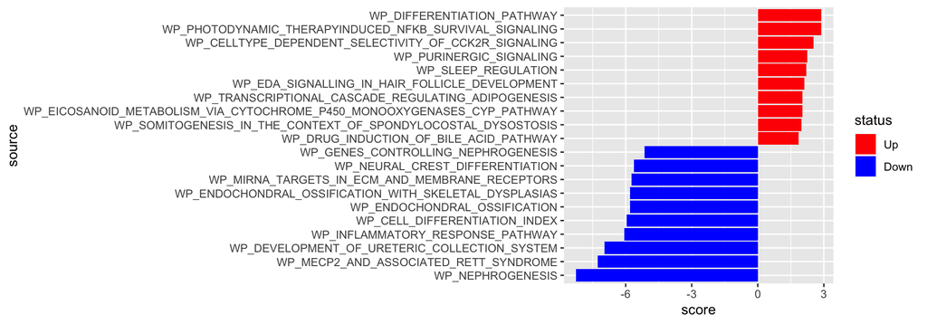

```r
plot_fcs_results <- function(df) {

  p <- df %>%
    dplyr::mutate(status = ifelse(score > 0, "Up", "Down")) %>%
    dplyr::arrange(p_value) %>%
    dplyr::group_by(status) %>%
    dplyr::slice_head(n = 10) %>%
    dplyr::arrange(score) %>%
    dplyr::mutate(source = forcats::fct_inorder(source)) %>%
    ggplot2::ggplot(aes(x = score, y = source, fill = status)) +
    ggplot2::geom_bar(stat = "identity") +
    ggplot2::scale_fill_manual(values = c("Up" = "red", "Down" = "blue"))

  return(p)

}

plot_fcs_results(wmean_results)
```

# Footprint-based analyses

DoRothEA and PROGENy are prior knowledge resources which we can couple with a statistical method to extract insights about biological activities from transcriptomic data.

## DoRothEA

We use [DoRothEA](https://github.com/saezlab/dorothea) to define TF-gene regulatory mechanisms and perform TF activity estimation.

```r
dorothea_interactions <- dorothea::dorothea_hs %>%
  subset(confidence %in% c("A", "B", "C")) %>%
  dplyr::mutate(likelihood = 1)

head(dorothea_interactions)
```

```
## # A tibble: 6 × 5
##   tf    confidence target   mor likelihood
##   <chr> <chr>      <chr>  <dbl>      <dbl>
## 1 AHR   C          CYP1A1     1          1
## 2 AHR   C          CYP1A2     1          1
## 3 AHR   C          CYP1B1     1          1
## 4 AHR   C          FOS        1          1
## 5 AHR   C          MYC        1          1
## 6 AHR   C          UGT1A6     1          1
```

We apply the `run_wmean()` function from `decoupler` using the functional sets defined by DoRothEA TFs.

```r
tf_activity_results <- run_wmean(
  mat = decoupler_input,
  network =dorothea_interactions,
  times = 2000,
  .source = "tf",
  .target = "target",
  .mor = "mor",
  .likelihood = "likelihood"
) %>%
  subset(statistic == "norm_wmean") %>%
  dplyr::mutate(adj_p = p.adjust(p_value, method = "BH"))
```

Visualize the top altered TFs

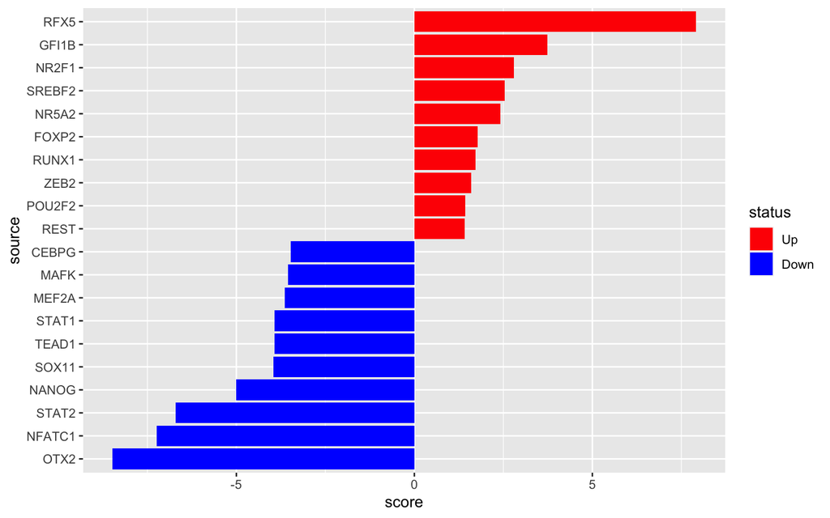

```r
plot_fcs_results(tf_activity_results)
```

## PROGENy

We use [PROGENy](https://github.com/saezlab/progeny) to connect transcriptomic changes to protein signalling pathway perturbations.

```r
# adapt progeny interactions to decoupler format
progeny_interactions <-
  progeny::getModel(organism = "Human", top = 300) %>%
  as.data.frame() %>%
  tibble::rownames_to_column(var = "target") %>%
  tidyr::pivot_longer(-target, names_to = "pathway", values_to = "weight") %>%
  subset(weight != 0) %>%
  dplyr::mutate(mor = sign(weight), likelihood = abs(weight))

# show the first interactions
head(subset(progeny_interactions, weight != 0))
```

```
## # A tibble: 6 × 5
##   target pathway  weight   mor likelihood
##   <chr>  <chr>     <dbl> <dbl>      <dbl>
## 1 A2M    PI3K      -4.13    -1       4.13
## 2 AAMDC  MAPK      -1.19    -1       1.19
## 3 AASS   VEGF      -2.77    -1       2.77
## 4 ABCA1  Estrogen  -2.93    -1       2.93
## 5 ABCA12 p53        9.60     1       9.60
## 6 ABCA5  EGFR      -1.81    -1       1.81
```

Perform the pathway activity estimation using `decoupler`.

```r
progeny_results <- run_wmean(
  mat = decoupler_input,
  network = progeny_interactions,
  times = 2000,
  .source = "pathway",
  .target = "target",
  .mor = "mor",
  .likelihood = "likelihood"
) %>%
  subset(statistic == "norm_wmean") %>%
  dplyr::mutate(adj_p = p.adjust(p_value, method = "BH"))
```

Visualize the results

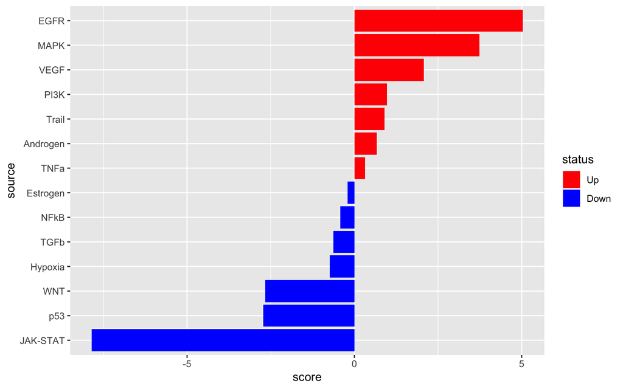

```r
plot_fcs_results(progeny_results)
```